# IML Group 20 Project AHH

Andrew Armstrong

2024-11-23

## Intro

This file contains the initial exploration into linear regression, including polynomial regression, multivariate regression, lasso, transformations, and stepwise selections.

## Generic model fit

First we’ll fit a model that just has every predictor as is (this will not be very accurate probably). I will specifically make the variables which should be treated as categorical as categorical (anything with the number of unique entries <= 10) and evaluate the accuracy.

```r
setwd("~/R Files/IML2024/Exercises/Exercise set 1")
training_data <- read.csv("train.csv")
#cut the columns deemed unnecessary initially
training_data <- subset(training_data, select = -c(ID,parentspecies))
training_data[] <- lapply(training_data, function(x) {
  if(length(unique(x))<11) as.factor(x) else x
})
```

```r
library(dplyr)
library(glmnet)
initial_model <- lm(log_pSat_Pa ~ .,training_data)
initial_model %>% summary()
```

```
##
## Call:
## lm(formula = log_pSat_Pa ~ ., data = training_data)
##
## Residuals:
##      Min       1Q   Median       3Q      Max
## -13.8203  -0.9880  -0.0123   0.9778  12.3266
##
## Coefficients: (3 not defined because of singularities)
##                                 Estimate Std. Error t value Pr(>|t|)
## (Intercept)                    8.175e+00  1.215e+00   6.728 1.76e-11 ***
## MW                            -1.179e-01  2.283e-02  -5.167 2.40e-07 ***
## NumOfAtoms                     1.423e-01  3.403e-02   4.182 2.90e-05 ***
## NumOfC2                       -4.799e-01  1.286e+00  -0.373  0.70915
## NumOfC3                       -7.585e-01  1.300e+00  -0.583  0.55963
## NumOfC4                       -7.044e-01  1.399e+00  -0.503  0.61462
## NumOfC5                       -4.629e-01  1.533e+00  -0.302  0.76272
## NumOfC6                       -1.515e-01  1.691e+00  -0.090  0.92862
## NumOfC7                        1.228e-01  1.865e+00   0.066  0.94750
## NumOfC8                        4.398e-01  2.053e+00   0.214  0.83040
## NumOfC9                        9.677e-01  2.249e+00   0.430  0.66702
## NumOfC10                       1.481e+00  2.452e+00   0.604  0.54581
## NumOfO                         2.233e+00  3.962e-01   5.637 1.75e-08 ***
## NumOfN1                        6.335e-02  2.340e-02   2.708  0.00678 **
## NumOfN2                               NA         NA      NA       NA
## NumHBondDonors1               -3.611e+00  3.100e-01 -11.648  < 2e-16 ***
## NumHBondDonors2               -6.873e+00  6.101e-01 -11.264  < 2e-16 ***
## NumHBondDonors3               -1.025e+01  9.130e-01 -11.223  < 2e-16 ***
## NumHBondDonors4               -1.381e+01  1.217e+00 -11.354  < 2e-16 ***
## NumHBondDonors5               -1.736e+01  1.524e+00 -11.393  < 2e-16 ***
## NumHBondDonors6               -2.089e+01  1.880e+00 -11.113  < 2e-16 ***
## NumOfConf                     -2.590e-03  9.399e-05 -27.558  < 2e-16 ***
## NumOfConfUsed                 -2.686e-03  1.005e-03  -2.673  0.00753 **
## C.C..non.aromatic.1           -7.348e-01  5.341e-02 -13.758  < 2e-16 ***
## C.C..non.aromatic.2            2.012e+00  7.660e-01   2.626  0.00864 **
## C.C.C.O.in.non.aromatic.ring1  2.936e-02  1.145e-01   0.256  0.79771
## C.C.C.O.in.non.aromatic.ring2  3.777e-01  2.749e-01   1.374  0.16956
## hydroxyl..alkyl.1              1.202e+00  2.770e-01   4.339 1.44e-05 ***
## hydroxyl..alkyl.2              2.306e+00  5.529e-01   4.170 3.06e-05 ***
## hydroxyl..alkyl.3              3.729e+00  8.305e-01   4.491 7.13e-06 ***
```

[output cut: 27 more lines]

```
## hydroperoxide1                 4.257e-01  2.590e-01   1.644  0.10026
## hydroperoxide2                 8.187e-01  5.175e-01   1.582  0.11367
## hydroperoxide3                 1.258e+00  7.842e-01   1.604  0.10864
## hydroperoxide4                 1.249e+00  1.984e+00   0.630  0.52881
## carbonylperoxyacid1           -2.005e-01  2.536e-01  -0.791  0.42922
## carbonylperoxyacid2           -7.331e-01  5.132e-01  -1.429  0.15314
## carbonylperoxyacid3                   NA         NA      NA       NA
## nitroester1                   -1.922e-01  1.373e-01  -1.400  0.16142
## nitroester2                   -1.961e+00  7.820e-01  -2.508  0.01213 *
## ---
## Signif. codes:  0 '***' 0.001 '**' 0.01 '*' 0.05 '.' 0.1 ' ' 1
##
## Residual standard error: 1.692 on 26574 degrees of freedom
## Multiple R-squared:  0.7065, Adjusted R-squared:  0.7058
## F-statistic:  1032 on 62 and 26574 DF,  p-value: < 2.2e-16
```

```r
### accuracy
initial_MSE <- mean((training_data$log_pSat_Pa - predict(initial_model))^2)
#dummy model accuracy:
dummy_MSE <- mean((training_data$log_pSat_Pa-mean(training_data$log_pSat_Pa))^2)
initial_MSE
```

```
## [1] 2.856973
```

```r
dummy_MSE
```

```
## [1] 9.735229
```

This actually doesn’t look terrible? but we’re probably violating some assumptions plus the model doesn’t have all significant values. Let’s do a lasso/ridge cross validation on this to see how that would perform:

```r
x <- model.matrix(log_pSat_Pa ~ ., data = training_data)[, -1]
y <- training_data$log_pSat_Pa
lasso_model <- cv.glmnet(x, y, alpha = 1, nfolds = 5)
lasso_coefficients <- coef(lasso_model, s = "lambda.min")
print(lasso_coefficients)
```

```
## 66 x 1 sparse Matrix of class "dgCMatrix"
##                                         s1
## (Intercept)                    1.181263926
## MW                             .
## NumOfAtoms                    -0.065013631
## NumOfC2                        4.560832636
## NumOfC3                        3.312272464
## NumOfC4                        2.320098521
## NumOfC5                        1.512888543
## NumOfC6                        0.766406807
## NumOfC7                       -0.008061137
## NumOfC8                       -0.721940775
## NumOfC9                       -1.250646077
## NumOfC10                      -1.776281213
## NumOfO                         0.018485880
## NumOfN1                        0.114504409
## NumOfN2                        0.102408499
## NumHBondDonors1               -1.637261616
## NumHBondDonors2               -3.015505667
## NumHBondDonors3               -4.496926122
## NumHBondDonors4               -6.168879752
## NumHBondDonors5               -7.816030627
## NumHBondDonors6               -9.395656061
## NumOfConf                     -0.002323963
## NumOfConfUsed                 -0.001080958
## C.C..non.aromatic.1           -0.898610928
## C.C..non.aromatic.2            1.550660104
## C.C.C.O.in.non.aromatic.ring1 -0.044628985
## C.C.C.O.in.non.aromatic.ring2  0.268437379
## hydroxyl..alkyl.1             -0.195321129
## hydroxyl..alkyl.2             -0.485245560
## hydroxyl..alkyl.3             -0.463132142
## hydroxyl..alkyl.4              .
## hydroxyl..alkyl.5              0.190386443
## aldehyde1                     -0.261734955
## aldehyde2                     -0.442690374
## aldehyde3                     -0.630418477
## aldehyde4                     -0.258943634
## ketone1                        0.024309823
## ketone2                        0.052155023
```

[output cut: 13 more lines]

```
## aromatic.hydroxyl1            -0.827149995
## aromatic.hydroxyl2            -3.042905702
## aromatic.hydroxyl3            -4.439103770
## carbonylperoxynitrate1         0.973136496
## carbonylperoxynitrate2         1.779872094
## peroxide1                     -0.899230137
## hydroperoxide1                -0.457538196
## hydroperoxide2                -0.955528330
## hydroperoxide3                -1.402742828
## hydroperoxide4                -2.115833644
## carbonylperoxyacid1           -0.664994089
## carbonylperoxyacid2           -1.672904647
## carbonylperoxyacid3           -1.330482426
## nitroester1                    0.521904073
## nitroester2                   -0.578313663
```

```r
lasso_MSE <- mean((training_data$log_pSat_Pa - predict(lasso_model, newx = x, s = "lambda.min"))^2)

ridge_model <- cv.glmnet(x, y, alpha = 0, nfolds = 5)
ridge_coefficients <- coef(ridge_model, s = "lambda.min")
print(ridge_coefficients)
```

```
## 66 x 1 sparse Matrix of class "dgCMatrix"
##                                         s1
## (Intercept)                    1.361397814
## MW                            -0.005694184
## NumOfAtoms                    -0.091021610
## NumOfC2                        3.866709939
## NumOfC3                        2.642954457
## NumOfC4                        1.686560871
## NumOfC5                        1.003964067
## NumOfC6                        0.415628091
## NumOfC7                       -0.190600978
## NumOfC8                       -0.584259508
## NumOfC9                       -0.946971051
## NumOfC10                      -1.283810606
## NumOfO                        -0.083598267
## NumOfN1                        0.536857172
## NumOfN2                        1.014580214
## NumHBondDonors1                0.007826081
## NumHBondDonors2               -0.616966025
## NumHBondDonors3               -1.339678940
## NumHBondDonors4               -2.238977582
## NumHBondDonors5               -3.125296531
## NumHBondDonors6               -4.015905709
## NumOfConf                     -0.002528260
## NumOfConfUsed                  0.000431211
## C.C..non.aromatic.1           -0.891404622
## C.C..non.aromatic.2            1.647227730
## C.C.C.O.in.non.aromatic.ring1 -0.158782588
## C.C.C.O.in.non.aromatic.ring2  0.193316063
## hydroxyl..alkyl.1             -0.666901488
## hydroxyl..alkyl.2             -1.410609315
## hydroxyl..alkyl.3             -1.880211865
## hydroxyl..alkyl.4             -1.932408205
## hydroxyl..alkyl.5             -2.079510953
## aldehyde1                     -0.045917694
## aldehyde2                     -0.012574190
## aldehyde3                      0.087246515
## aldehyde4                      0.951066351
## ketone1                        0.201332232
## ketone2                        0.429200252
```

[output cut: 13 more lines]

```
## aromatic.hydroxyl1            -1.427679057
## aromatic.hydroxyl2            -3.991034809
## aromatic.hydroxyl3            -5.896202809
## carbonylperoxynitrate1         1.607158243
## carbonylperoxynitrate2         3.043134071
## peroxide1                     -0.436751583
## hydroperoxide1                -0.722337996
## hydroperoxide2                -1.437691331
## hydroperoxide3                -2.145172744
## hydroperoxide4                -3.255871710
## carbonylperoxyacid1           -0.733967992
## carbonylperoxyacid2           -1.776692803
## carbonylperoxyacid3           -1.642903578
## nitroester1                    0.899716073
## nitroester2                   -0.042205804
```

```r
ridge_MSE <- mean((training_data$log_pSat_Pa - predict(ridge_model, newx = x, s = "lambda.min"))^2)
#Elastic net method
ELN_model <- cv.glmnet(x, y, alpha = .5, nfolds = 5)
ELN_coefficients <- coef(ELN_model, s = "lambda.min")
print(ELN_coefficients)
```

```
## 66 x 1 sparse Matrix of class "dgCMatrix"
##                                         s1
## (Intercept)                    1.163655045
## MW                             .
## NumOfAtoms                    -0.061408927
## NumOfC2                        4.573756440
## NumOfC3                        3.303234674
## NumOfC4                        2.298560142
## NumOfC5                        1.480288752
## NumOfC6                        0.723058225
## NumOfC7                       -0.063706113
## NumOfC8                       -0.792206486
## NumOfC9                       -1.331234477
## NumOfC10                      -1.867663623
## NumOfO                         0.033988862
## NumOfN1                        0.063865474
## NumOfN2                        .
## NumHBondDonors1               -1.165704613
## NumHBondDonors2               -2.056078412
## NumHBondDonors3               -3.049703932
## NumHBondDonors4               -4.235258232
## NumHBondDonors5               -5.402345653
## NumHBondDonors6               -6.556003278
## NumOfConf                     -0.002336378
## NumOfConfUsed                 -0.001210487
## C.C..non.aromatic.1           -0.889646755
## C.C..non.aromatic.2            1.601627519
## C.C.C.O.in.non.aromatic.ring1 -0.047032908
## C.C.C.O.in.non.aromatic.ring2  0.283284636
## hydroxyl..alkyl.1             -0.698760284
## hydroxyl..alkyl.2             -1.493385525
## hydroxyl..alkyl.3             -1.974569751
## hydroxyl..alkyl.4             -1.999446789
## hydroxyl..alkyl.5             -2.122548326
## aldehyde1                     -0.274138453
## aldehyde2                     -0.467012453
## aldehyde3                     -0.671432836
## aldehyde4                     -0.357266135
## ketone1                        0.016124884
## ketone2                        0.033289499
```

[output cut: 13 more lines]

```
## aromatic.hydroxyl1            -1.326231518
## aromatic.hydroxyl2            -4.053256467
## aromatic.hydroxyl3            -5.969401590
## carbonylperoxynitrate1         0.940219006
## carbonylperoxynitrate2         1.716768236
## peroxide1                     -0.937477370
## hydroperoxide1                -0.978361447
## hydroperoxide2                -1.996880473
## hydroperoxide3                -2.967322860
## hydroperoxide4                -4.272082931
## carbonylperoxyacid1           -1.201273369
## carbonylperoxyacid2           -2.747032654
## carbonylperoxyacid3           -2.971209417
## nitroester1                    0.502431309
## nitroester2                   -0.661274725
```

```r
ELN_MSE <- mean((training_data$log_pSat_Pa - predict(ELN_model, newx = x, s = "lambda.min"))^2)
```

```r
lasso_MSE
```

```
## [1] 2.868473
```

```r
ridge_MSE
```

```
## [1] 2.919436
```

```r
ELN_MSE
```

```
## [1] 2.867738
```

These results seem to indicate that there are indeed some variables that can be excluded from the model like MW, though with the categorical variables this is harder to know what to do given that it’s an all or nothing situation (unless we reduce the categories).

The MSE does not go up signficantly from our initial model which is good, but I think it does indicate a better model might exist somewhere.

### Variable Transformation

Let’s look at our histograms and variables more closely to see if any need transformation:

```r
df <- training_data
par(mfrow = c(ceiling(sqrt(ncol(df))), ceiling(sqrt(ncol(df))))) # Set layout for plots
par(mar = c(2, 2, 2, 2))
lapply(df, function(column) {
  if (is.numeric(column)) {
    hist(column, main = colnames(df)[which(sapply(df, identical, column))],
         xlab = "Values",
         ylab = "Frequency",
         col = "lightblue",
         border = "white")
  }
})
```

[output not shown]

[output cut: 159 more lines]

[output not shown]

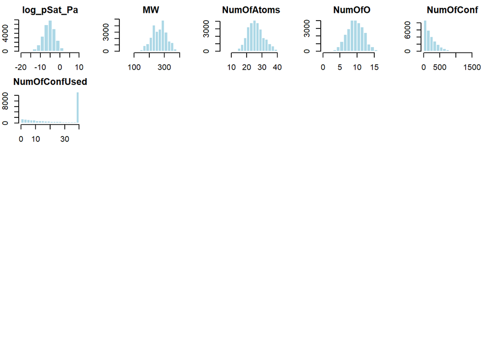

```r
par(mfrow = c(1, 1))
```

NumOfConfUsed and NumOfConf do not appear to be very normal in their histograms, which means we can transform them. Let’s use BoxCox for this transformation:

```r
library(MASS)
boxcox_result <- boxcox(lm(NumOfConf ~ 1, data = training_data))
```

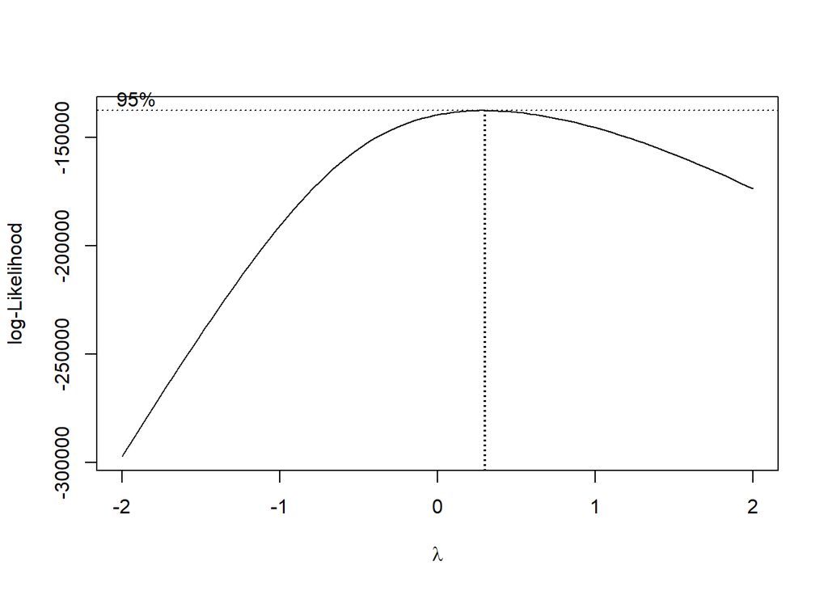

```r
lambda_Conf <- boxcox_result$x[which.max(boxcox_result$y)]
boxcox_result <- boxcox(lm(NumOfConfUsed ~ 1, data = training_data))
```

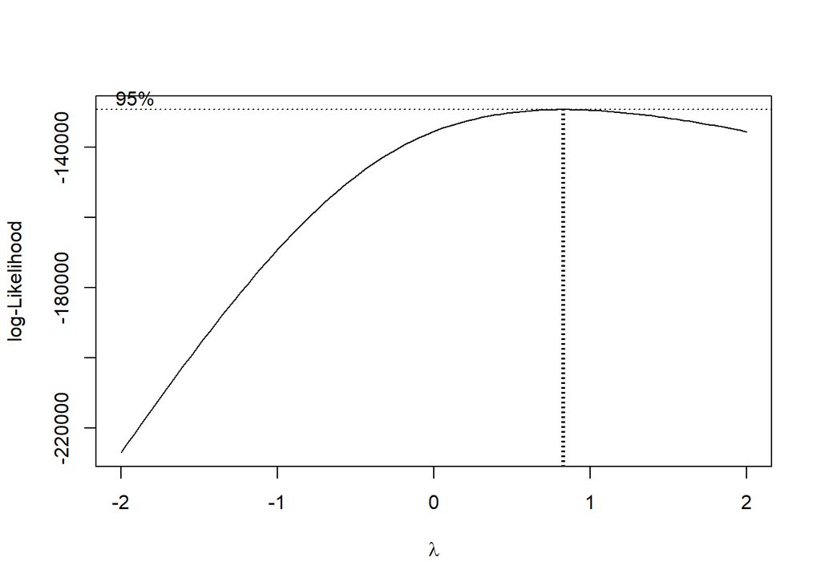

```r
lambda_Used <- boxcox_result$x[which.max(boxcox_result$y)]
training_data$NumOfConf <- (training_data$NumOfConf^lambda_Conf - 1) / lambda_Conf
training_data$NumOfConfUsed <- (training_data$NumOfConfUsed^lambda_Used - 1) / lambda_Used
```

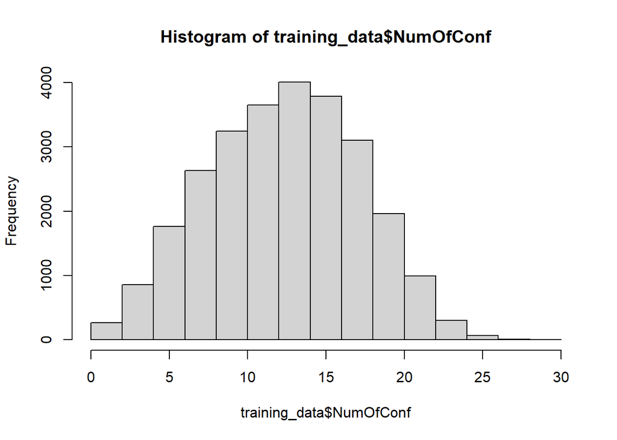

```r
hist(training_data$NumOfConf)
```

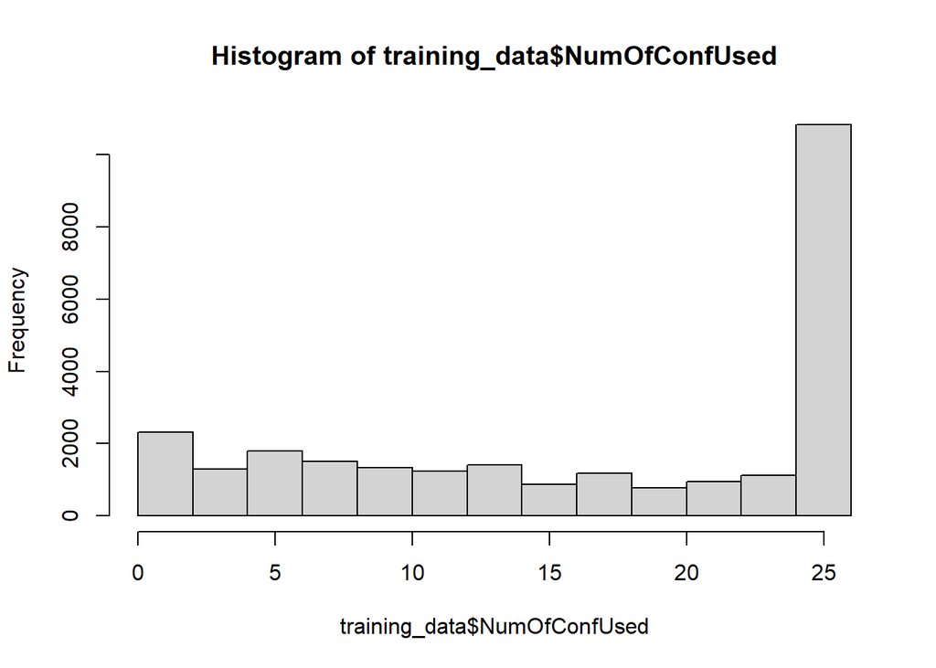

```r
hist(training_data$NumOfConfUsed)
```

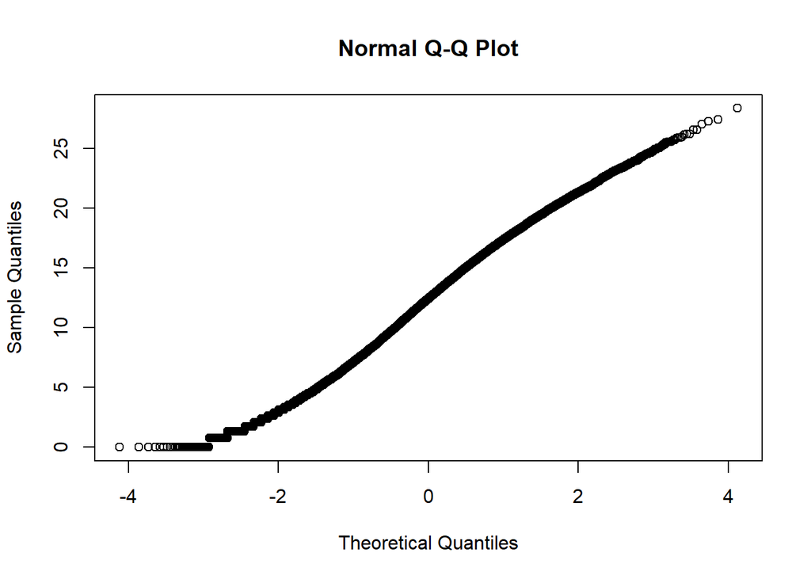

```r
qqnorm(training_data$NumOfConf)
```

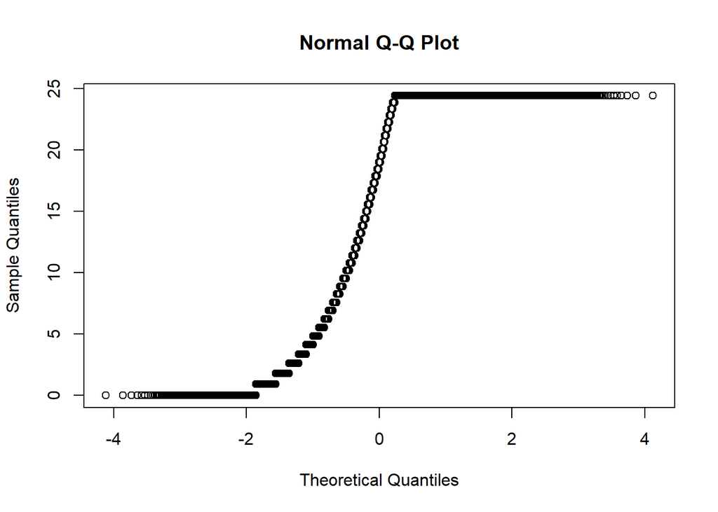

```r
qqnorm(training_data$NumOfConfUsed)
```

NumOfConf looks much more normal but NumOfConfUsed much less so. If we can not use NumOfConfUsed (or maybe turn it categorical) we might have a better model here.

## Stepwise Model selection?

Choosing the factors to include/exclude can be based on the lasso/ridge/ELN models above, but we can also do some individual plots to see what should have a relationship with log_pSat_Pa in some way (it may not be fully linear but if something happens then we can include it and if nothing happens then we can drop it).

### Plot of everything

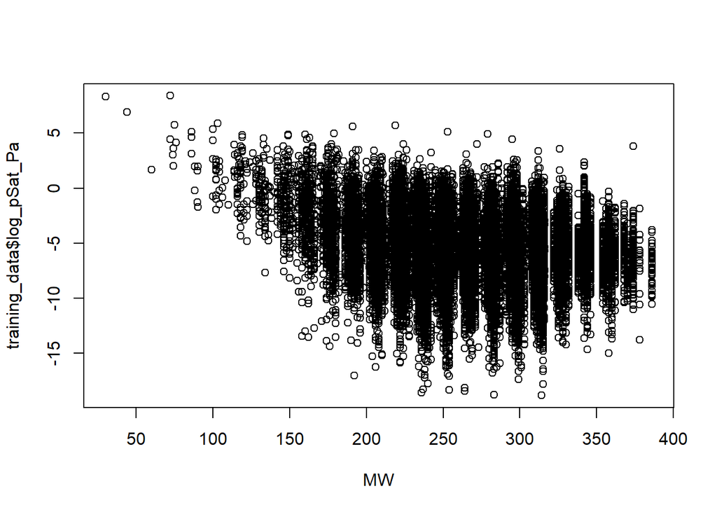

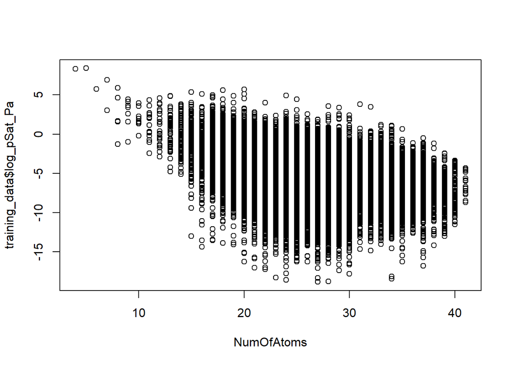

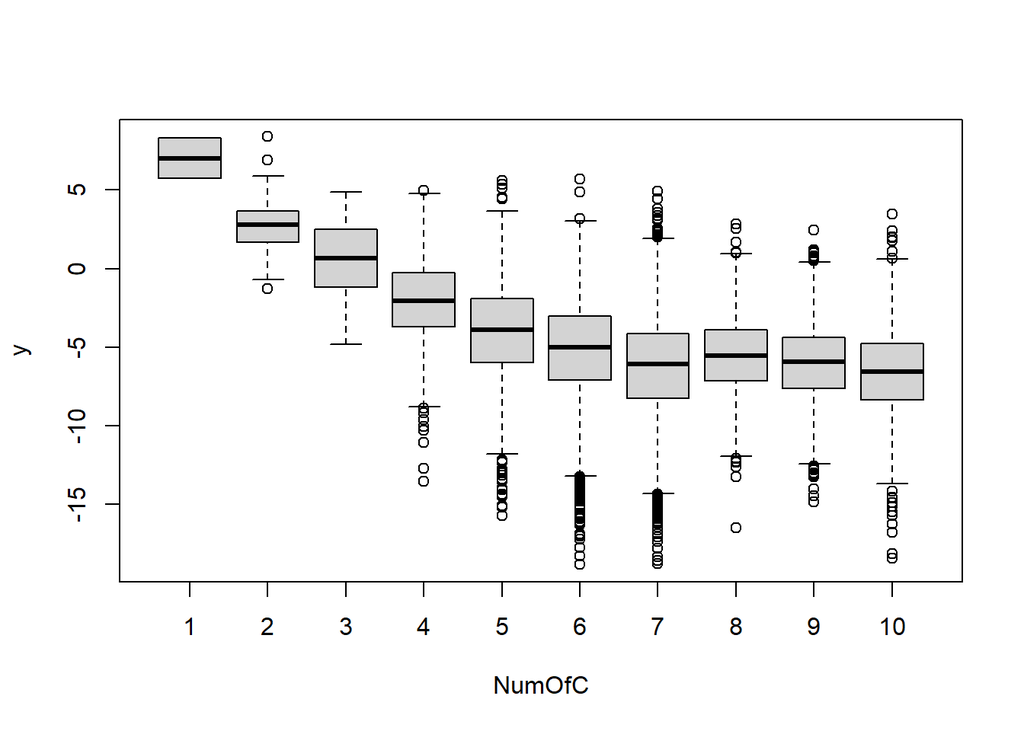

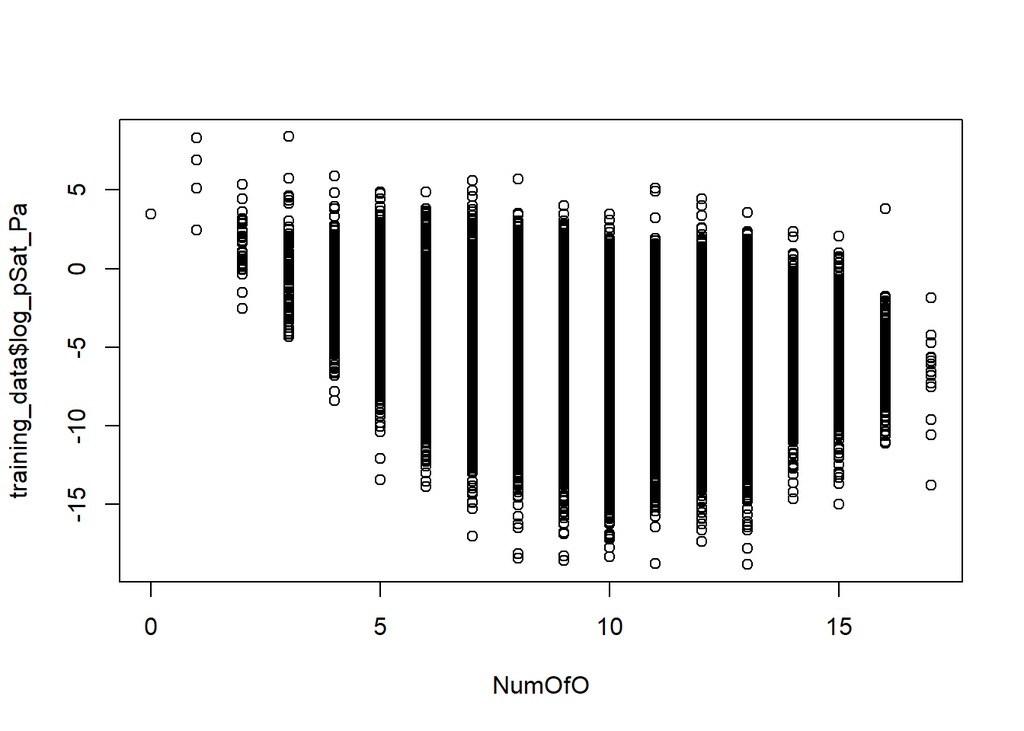

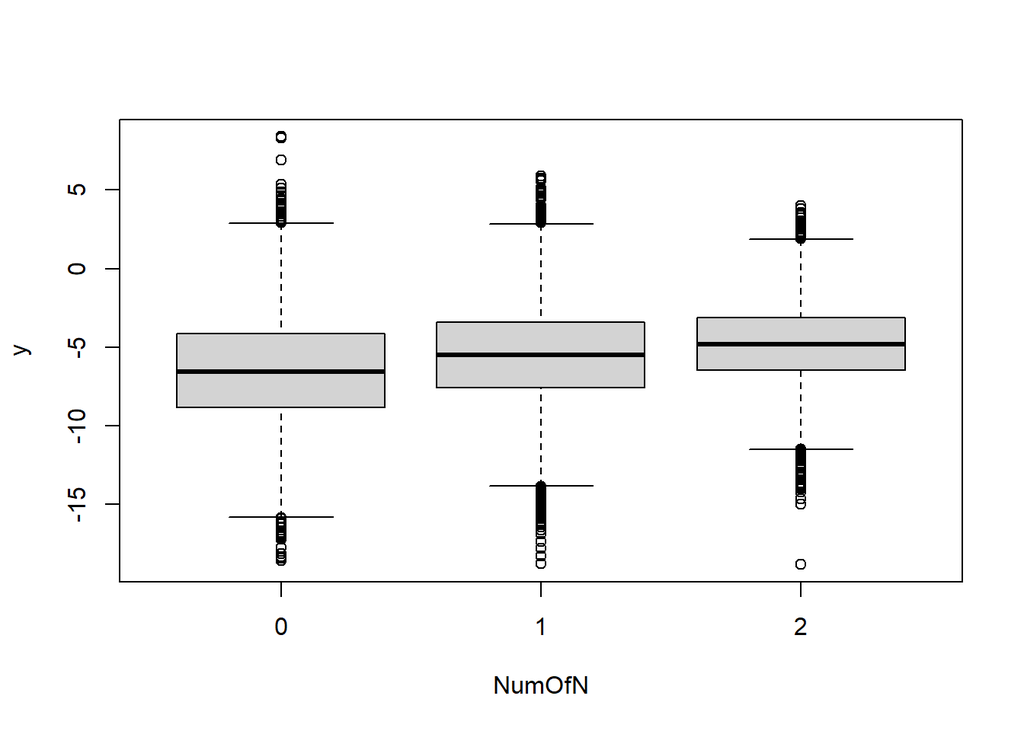

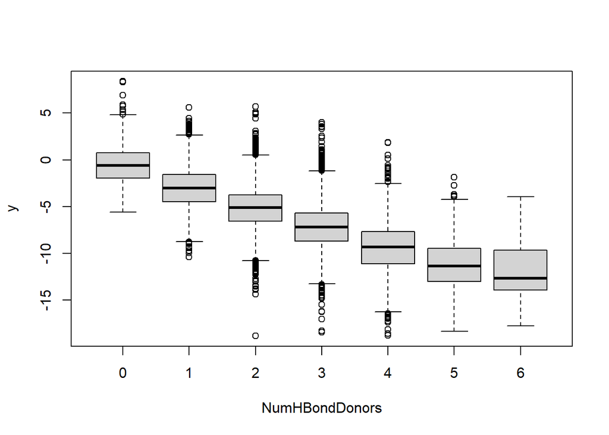

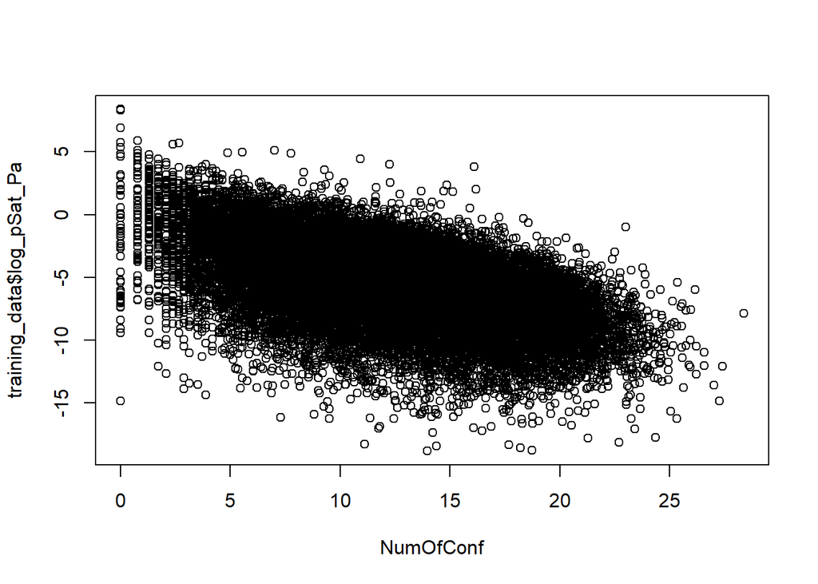

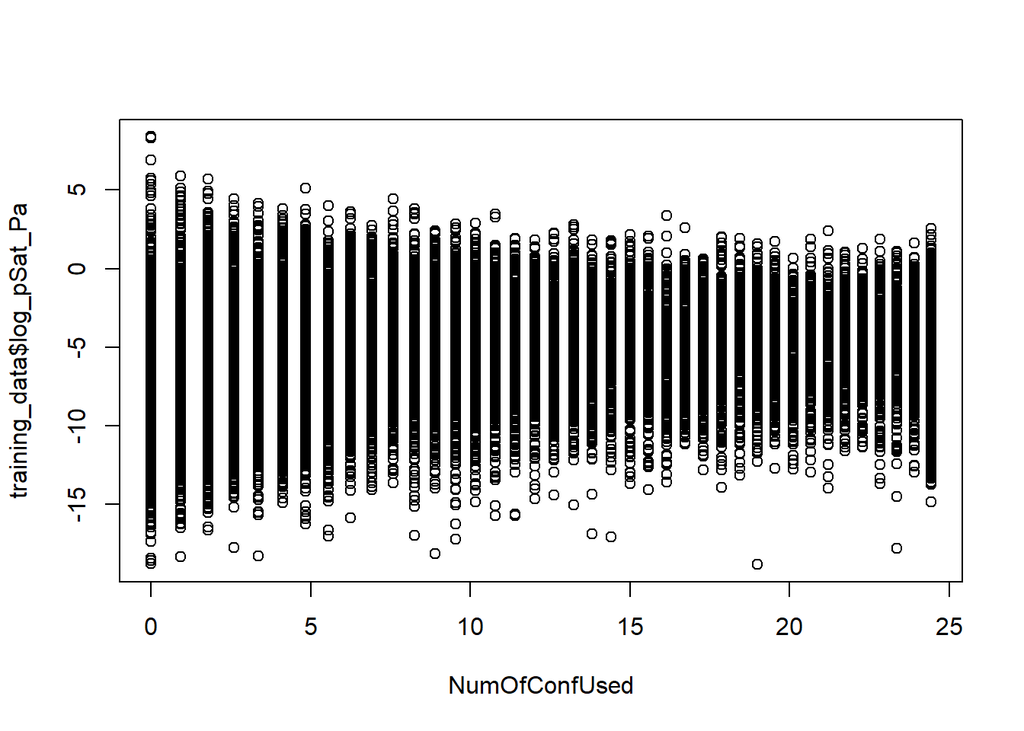

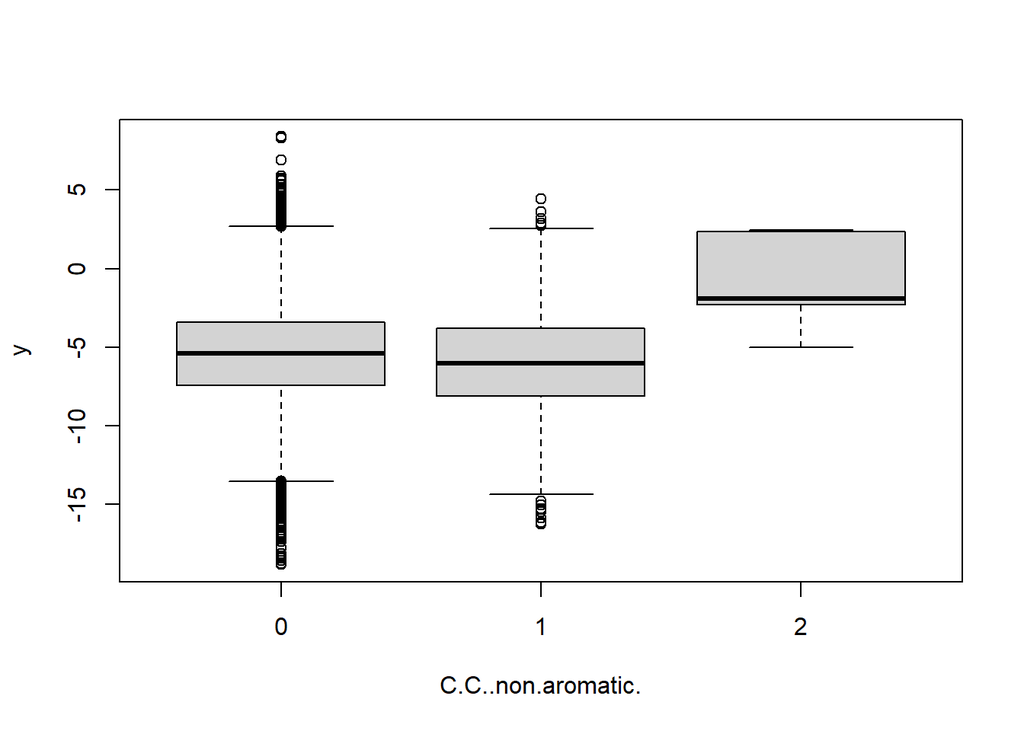

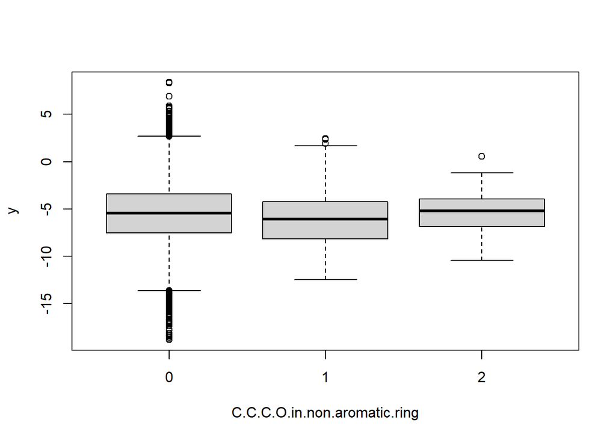

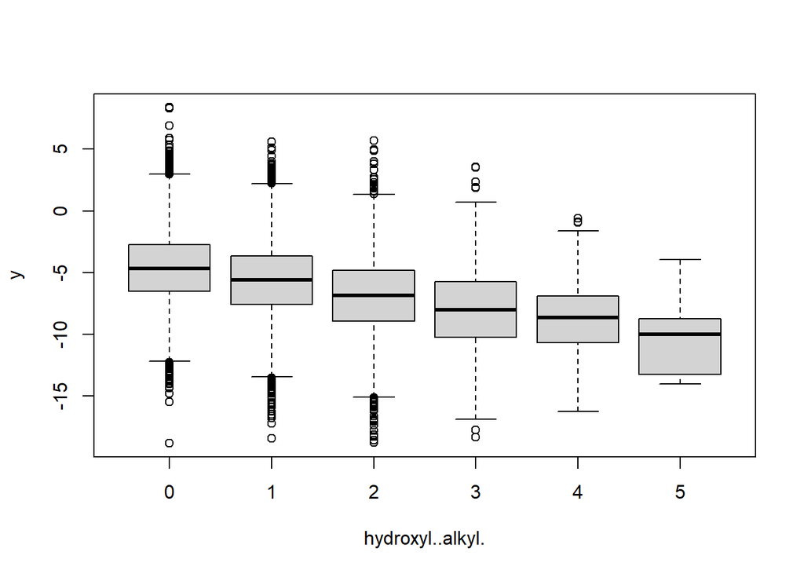

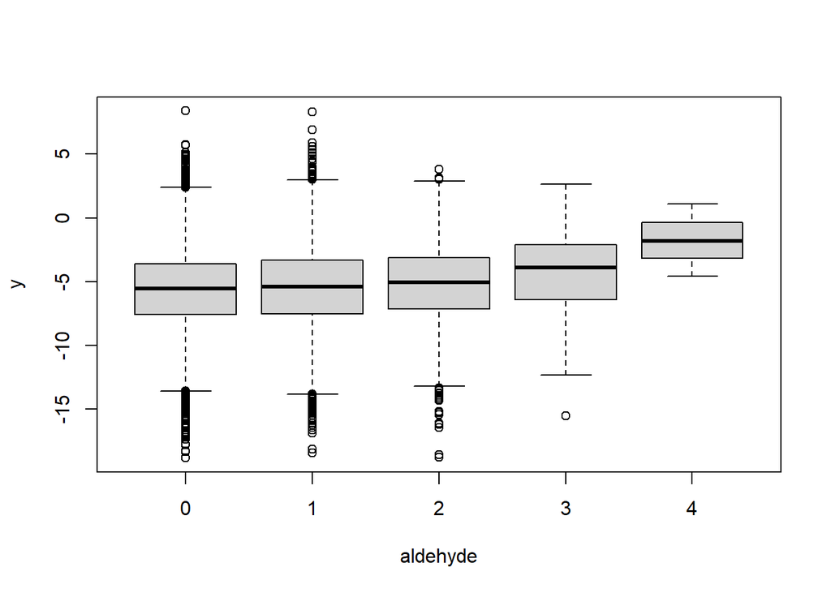

[12 more figures not shown]

```r
for(i in 2:25){
  plot(training_data[,i],training_data$log_pSat_Pa, xlab = colnames(training_data)[i])
}
```

The variables that have a (somewhat linear) or maybe polynomial relationship with log_pSat_Pa are: MW, NumOfAtoms, NumOfO, NumOfC, NumOfConf (transformed),NumHBondDonors, hydroxyl..alkyl,aldehyde, ketone,carboxylic.acid, carbonylperoxynitrate, hydroperoxide, nitroester, carbonylperoxyacid

The variables that have some change in variance, but maybe not an actual relationship, are: NumOfN, NumOfConfUsed, C.C..non.aromatic., C.C.C.O.in.non.aromatic.ring, ester, ester..alicyclic, nitrate, nitro, aromatic.hydroxyl, peroxide

Some of these categorical variables are indicating that some of their higher values can possibly be consolidated into smaller categories. Nitroester for example, suggests that there’s a different distribution for values of 1 or greater. We can explore this later possibly?

I’m going to fit a linear model of poly order two with interactions for the variables we identified as probably having a most obvious relationship with log_pSat_Pa. We can think to include the other ones later but right now they dont indicate much of an obvious relationship. I will however include the transformed NumOfConfUsed as that in principle feels like it should interact with NumOfConf. This will be computationally expensive but from this model we can eliminate unnecessary terms with stepwise selection.

```r
subset_model <- lm(log_pSat_Pa ~
                     (MW + NumOfAtoms + NumOfO + NumOfC + NumOfConf + NumOfConfUsed + NumHBondDonors + hydroxyl..alkyl. + aldehyde + ketone +carboxylic.acid + carbonylperoxynitrate + hydroperoxide + nitroester + carbonylperoxyacid)^2, training_data)
```

```r
subset_model %>% summary()
```

```
##
## Call:
## lm(formula = log_pSat_Pa ~ (MW + NumOfAtoms + NumOfO + NumOfC +
##     NumOfConf + NumOfConfUsed + NumHBondDonors + hydroxyl..alkyl. +
##     aldehyde + ketone + carboxylic.acid + carbonylperoxynitrate +
##     hydroperoxide + nitroester + carbonylperoxyacid)^2, data = training_data)
##
## Residuals:
##      Min       1Q   Median       3Q      Max
## -14.8458  -0.8949   0.0000   0.8802  13.2807
##
## Coefficients: (438 not defined because of singularities)
##                                              Estimate Std. Error t value
## (Intercept)                                 3.317e+01  3.775e+00   8.788
## MW                                         -9.501e-01  8.504e-02 -11.173
## NumOfAtoms                                 -1.536e+00  2.474e-01  -6.211
## NumOfO                                      1.730e+01  1.323e+00  13.079
## NumOfC2                                    -2.242e+01  4.542e+00  -4.936
## NumOfC3                                    -1.989e+01  3.769e+00  -5.278
## NumOfC4                                    -1.455e+01  3.421e+00  -4.255
## NumOfC5                                    -8.439e+00  3.286e+00  -2.568
## NumOfC6                                     1.737e+00  3.385e+00   0.513
## NumOfC7                                     1.118e+01  3.734e+00   2.995
## NumOfC8                                     2.268e+01  5.522e+00   4.108
## NumOfC9                                     3.817e+01  6.209e+00   6.149
## NumOfC10                                    5.467e+01  7.102e+00   7.697
## NumOfConf                                   1.012e+00  1.830e-01   5.532
## NumOfConfUsed                              -1.563e-01  6.605e-02  -2.367
## NumHBondDonors1                            -6.310e+01  2.729e+01  -2.312
## NumHBondDonors2                            -1.237e+02  5.049e+01  -2.449
## NumHBondDonors3                            -1.791e+02  7.402e+01  -2.420
## NumHBondDonors4                            -2.273e+02  9.825e+01  -2.314
## NumHBondDonors5                            -3.235e+02  1.289e+02  -2.509
## NumHBondDonors6                            -3.967e+02  2.196e+02  -1.807
## hydroxyl..alkyl.1                           7.738e+01  3.113e+01   2.486
## hydroxyl..alkyl.2                           1.316e+02  5.847e+01   2.250
## hydroxyl..alkyl.3                           1.498e+02  7.280e+01   2.057
## hydroxyl..alkyl.4                           1.773e+02  9.817e+01   1.807
## hydroxyl..alkyl.5                           3.717e+02  2.717e+02   1.368
## aldehyde1                                  -8.691e+00  1.107e+00  -7.851
```

[output cut: 2137 more lines]

```
## hydroperoxide2:carbonylperoxyacid3               NA
## hydroperoxide3:carbonylperoxyacid3               NA
## hydroperoxide4:carbonylperoxyacid3               NA
## nitroester1:carbonylperoxyacid1            0.828890
## nitroester2:carbonylperoxyacid1                  NA
## nitroester1:carbonylperoxyacid2                  NA
## nitroester2:carbonylperoxyacid2                  NA
## nitroester1:carbonylperoxyacid3                  NA
## nitroester2:carbonylperoxyacid3                  NA
## ---
## Signif. codes:  0 '***' 0.001 '**' 0.01 '*' 0.05 '.' 0.1 ' ' 1
##
## Residual standard error: 1.604 on 25989 degrees of freedom
## Multiple R-squared:  0.742,  Adjusted R-squared:  0.7356
## F-statistic: 115.5 on 647 and 25989 DF,  p-value: < 2.2e-16
```

```r
subset_MSE <- mean((training_data$log_pSat_Pa - predict(subset_model))^2)
#stepwise_model <- step(subset_model,
#                       scope = list(lower = ~1, upper = subset_model),
#                       direction = "backward")
#stepwise_model %>% summary()
```

Polynomial for linear objects fit (except NumOfConfUsed)

```r
subset_poly_model <- lm(log_pSat_Pa ~
                     (MW + I(MW^2) + NumOfAtoms + I(NumOfAtoms^2) + NumOfO + I(NumOfO^2) + NumOfC + NumOfConf + I(NumOfConf^2) + NumOfConfUsed + NumHBondDonors + hydroxyl..alkyl. + aldehyde + ketone +carboxylic.acid + carbonylperoxynitrate + hydroperoxide + nitroester + carbonylperoxyacid)^2, training_data)
subset_poly_model %>% summary()
```

```
##
## Call:
## lm(formula = log_pSat_Pa ~ (MW + I(MW^2) + NumOfAtoms + I(NumOfAtoms^2) +
##     NumOfO + I(NumOfO^2) + NumOfC + NumOfConf + I(NumOfConf^2) +
##     NumOfConfUsed + NumHBondDonors + hydroxyl..alkyl. + aldehyde +
##     ketone + carboxylic.acid + carbonylperoxynitrate + hydroperoxide +
##     nitroester + carbonylperoxyacid)^2, data = training_data)
##
## Residuals:
##      Min       1Q   Median       3Q      Max
## -14.4806  -0.8769   0.0000   0.8605  13.2104
##
## Coefficients: (472 not defined because of singularities)
##                                              Estimate Std. Error t value
## (Intercept)                                 4.602e+01  6.856e+00   6.713
## MW                                         -5.708e-01  6.171e-01  -0.925
## I(MW^2)                                    -1.256e-03  5.191e-03  -0.242
## NumOfAtoms                                 -4.903e+00  2.633e+00  -1.862
## I(NumOfAtoms^2)                             1.798e-01  8.683e-02   2.070
## NumOfO                                      1.258e+01  1.036e+01   1.215
## I(NumOfO^2)                                 4.784e-01  7.336e-01   0.652
## NumOfC2                                    -2.704e+01  4.478e+01  -0.604
## NumOfC3                                    -4.229e+01  8.168e+00  -5.178
## NumOfC4                                    -3.756e+01  8.099e+00  -4.638
## NumOfC5                                    -3.877e+01  1.061e+01  -3.656
## NumOfC6                                    -2.895e+01  1.391e+01  -2.080
## NumOfC7                                    -1.052e+01  1.767e+01  -0.595
## NumOfC8                                     6.953e+00  2.262e+01   0.307
## NumOfC9                                     6.925e+01  2.780e+01   2.491
## NumOfC10                                    1.170e+02  3.452e+01   3.388
## NumOfConf                                   2.946e+00  6.639e-01   4.438
## I(NumOfConf^2)                             -2.720e-02  2.427e-02  -1.121
## NumOfConfUsed                              -1.957e-01  9.793e-02  -1.999
## NumHBondDonors1                            -5.487e+02  2.476e+02  -2.216
## NumHBondDonors2                            -1.067e+03  4.851e+02  -2.200
## NumHBondDonors3                            -1.605e+03  7.308e+02  -2.196
## NumHBondDonors4                            -2.106e+03  9.683e+02  -2.175
## NumHBondDonors5                            -2.626e+03  1.212e+03  -2.167
## NumHBondDonors6                            -7.963e+03  9.677e+03  -0.823
## hydroxyl..alkyl.1                           5.260e+02  2.438e+02   2.158
```

[output cut: 2542 more lines]

```
## hydroperoxide2:carbonylperoxyacid3               NA
## hydroperoxide3:carbonylperoxyacid3               NA
## hydroperoxide4:carbonylperoxyacid3               NA
## nitroester1:carbonylperoxyacid1            0.705623
## nitroester2:carbonylperoxyacid1                  NA
## nitroester1:carbonylperoxyacid2                  NA
## nitroester2:carbonylperoxyacid2                  NA
## nitroester1:carbonylperoxyacid3                  NA
## nitroester2:carbonylperoxyacid3                  NA
## ---
## Signif. codes:  0 '***' 0.001 '**' 0.01 '*' 0.05 '.' 0.1 ' ' 1
##
## Residual standard error: 1.589 on 25821 degrees of freedom
## Multiple R-squared:  0.7486, Adjusted R-squared:  0.7407
## F-statistic: 94.36 on 815 and 25821 DF,  p-value: < 2.2e-16
```

```r
subset_poly_MSE <- mean((training_data$log_pSat_Pa - predict(subset_poly_model))^2)
#stepwise_poly_model <- step(subset_poly_model,
#                       scope = list(lower = ~1, upper = subset_poly_model),
#                       direction = "backward")
#stepwise_poly_model %>% summary()
```

```r
#step_MSE <- mean((training_data$log_pSat_Pa - predict(stepwise_model))^2)
#step_poly_MSE <- mean((training_data$log_pSat_Pa - predict(stepwise_poly_model))^2)
```

## Lasso, Ridge, ELN with these:

```r
x_subset <- model.matrix(log_pSat_Pa ~ (MW + NumOfAtoms + NumOfO + NumOfC + NumOfConf + NumOfConfUsed + NumHBondDonors + hydroxyl..alkyl. + aldehyde + ketone +carboxylic.acid + carbonylperoxynitrate + hydroperoxide + nitroester + carbonylperoxyacid)^2, data = training_data)[, -1]
y <- training_data$log_pSat_Pa
lasso_subset_model <- cv.glmnet(x_subset, y, alpha = 1, nfolds = 5)
lasso_coefficients <- coef(lasso_subset_model, s = "lambda.min")
print(lasso_coefficients)
```

```
## 1086 x 1 sparse Matrix of class "dgCMatrix"
##                                                       s1
## (Intercept)                                 5.315448e-01
## MW                                         -7.663868e-04
## NumOfAtoms                                  1.811084e-01
## NumOfO                                     -6.592457e-01
## NumOfC2                                     7.062279e+00
## NumOfC3                                     3.096441e+00
## NumOfC4                                     1.574400e+00
## NumOfC5                                     5.949860e-01
## NumOfC6                                     4.481036e-04
## NumOfC7                                    -6.347249e-01
## NumOfC8                                    -1.640346e+00
## NumOfC9                                    -3.201854e+00
## NumOfC10                                   -3.054042e+00
## NumOfConf                                  -8.233763e-02
## NumOfConfUsed                               4.416307e-03
## NumHBondDonors1                            -1.376742e+00
## NumHBondDonors2                            -4.168912e+00
## NumHBondDonors3                            -6.423367e+00
## NumHBondDonors4                            -7.433161e+00
## NumHBondDonors5                            -7.236053e+00
## NumHBondDonors6                            -8.081672e+00
## hydroxyl..alkyl.1                          -7.189992e-02
## hydroxyl..alkyl.2                           .
## hydroxyl..alkyl.3                           .
## hydroxyl..alkyl.4                          -2.276080e+00
## hydroxyl..alkyl.5                           .
## aldehyde1                                   .
## aldehyde2                                  -6.561306e-01
## aldehyde3                                  -5.592096e-02
## aldehyde4                                   .
## ketone1                                     .
## ketone2                                     .
## ketone3                                    -3.252267e-01
## ketone4                                     2.771499e-01
## ketone5                                     5.015021e-04
## carboxylic.acid1                           -7.411360e-01
## carboxylic.acid2                           -1.037550e+00
## carboxylic.acid3                           -1.261243e+00
```

[output cut: 1033 more lines]

```
## hydroperoxide4:carbonylperoxyacid1          .
## hydroperoxide1:carbonylperoxyacid2          .
## hydroperoxide2:carbonylperoxyacid2          .
## hydroperoxide3:carbonylperoxyacid2          .
## hydroperoxide4:carbonylperoxyacid2          .
## hydroperoxide1:carbonylperoxyacid3          .
## hydroperoxide2:carbonylperoxyacid3          .
## hydroperoxide3:carbonylperoxyacid3          .
## hydroperoxide4:carbonylperoxyacid3          .
## nitroester1:carbonylperoxyacid1             1.306107e-01
## nitroester2:carbonylperoxyacid1             .
## nitroester1:carbonylperoxyacid2             6.647339e-01
## nitroester2:carbonylperoxyacid2             .
## nitroester1:carbonylperoxyacid3             .
## nitroester2:carbonylperoxyacid3             .
```

```r
lasso_subset_MSE <- mean((training_data$log_pSat_Pa - predict(lasso_subset_model, newx = x_subset, s = "lambda.min"))^2)

ridge_subset_model <- cv.glmnet(x_subset, y, alpha = 0, nfolds = 5)
ridge_coefficients <- coef(ridge_subset_model, s = "lambda.min")
print(ridge_coefficients)
```

```
## 1086 x 1 sparse Matrix of class "dgCMatrix"
##                                                       s1
## (Intercept)                                -1.864857e+00
## MW                                         -1.722055e-03
## NumOfAtoms                                  4.340082e-02
## NumOfO                                     -9.952145e-02
## NumOfC2                                     4.602611e+00
## NumOfC3                                     2.092015e+00
## NumOfC4                                     9.335390e-01
## NumOfC5                                     4.091444e-01
## NumOfC6                                    -6.157851e-02
## NumOfC7                                    -2.512882e-01
## NumOfC8                                     2.121572e-01
## NumOfC9                                    -2.221271e-01
## NumOfC10                                   -1.156537e-01
## NumOfConf                                  -5.460041e-02
## NumOfConfUsed                               6.796439e-03
## NumHBondDonors1                             1.561495e-01
## NumHBondDonors2                            -3.235244e-01
## NumHBondDonors3                            -5.476240e-01
## NumHBondDonors4                            -6.556564e-01
## NumHBondDonors5                            -6.183500e-01
## NumHBondDonors6                            -8.137114e-01
## hydroxyl..alkyl.1                          -1.852341e-01
## hydroxyl..alkyl.2                          -4.628460e-01
## hydroxyl..alkyl.3                          -6.470158e-01
## hydroxyl..alkyl.4                          -9.023368e-01
## hydroxyl..alkyl.5                          -1.062476e+00
## aldehyde1                                   3.326908e-02
## aldehyde2                                  -6.896131e-02
## aldehyde3                                  -7.304374e-02
## aldehyde4                                   1.753647e-01
## ketone1                                     6.797110e-02
## ketone2                                     8.693782e-02
## ketone3                                     1.504431e-01
## ketone4                                     3.793930e-01
## ketone5                                     4.451966e-01
## carboxylic.acid1                           -4.073791e-01
## carboxylic.acid2                           -6.676933e-01
## carboxylic.acid3                           -1.371023e+00
```

[output cut: 1033 more lines]

```
## hydroperoxide4:carbonylperoxyacid1          .
## hydroperoxide1:carbonylperoxyacid2         -6.505914e-01
## hydroperoxide2:carbonylperoxyacid2          .
## hydroperoxide3:carbonylperoxyacid2          .
## hydroperoxide4:carbonylperoxyacid2          .
## hydroperoxide1:carbonylperoxyacid3          .
## hydroperoxide2:carbonylperoxyacid3          .
## hydroperoxide3:carbonylperoxyacid3          .
## hydroperoxide4:carbonylperoxyacid3          .
## nitroester1:carbonylperoxyacid1            -1.055701e-01
## nitroester2:carbonylperoxyacid1             .
## nitroester1:carbonylperoxyacid2             6.617308e-01
## nitroester2:carbonylperoxyacid2             .
## nitroester1:carbonylperoxyacid3             .
## nitroester2:carbonylperoxyacid3             .
```

```r
ridge_subset_MSE <- mean((training_data$log_pSat_Pa - predict(ridge_subset_model, newx = x_subset, s = "lambda.min"))^2)
#Elastic net method
ELN_subset_model <- cv.glmnet(x_subset, y, alpha = .5, nfolds = 5)
ELN_coefficients <- coef(ELN_subset_model, s = "lambda.min")
print(ELN_coefficients)
```

```
## 1086 x 1 sparse Matrix of class "dgCMatrix"
##                                                       s1
## (Intercept)                                 2.480788e-01
## MW                                         -1.280920e-03
## NumOfAtoms                                  1.855312e-01
## NumOfO                                     -6.158797e-01
## NumOfC2                                     7.301228e+00
## NumOfC3                                     3.240490e+00
## NumOfC4                                     1.628889e+00
## NumOfC5                                     6.596559e-01
## NumOfC6                                     2.644353e-04
## NumOfC7                                    -7.249798e-01
## NumOfC8                                    -1.720897e+00
## NumOfC9                                    -3.059085e+00
## NumOfC10                                   -3.060693e+00
## NumOfConf                                  -9.161228e-02
## NumOfConfUsed                               6.527443e-03
## NumHBondDonors1                            -5.831991e-01
## NumHBondDonors2                            -3.563097e+00
## NumHBondDonors3                            -5.091984e+00
## NumHBondDonors4                            -5.564421e+00
## NumHBondDonors5                            -5.579972e+00
## NumHBondDonors6                            -7.484039e+00
## hydroxyl..alkyl.1                          -2.201838e-01
## hydroxyl..alkyl.2                          -9.905732e-02
## hydroxyl..alkyl.3                           .
## hydroxyl..alkyl.4                          -3.085424e+00
## hydroxyl..alkyl.5                           .
## aldehyde1                                   .
## aldehyde2                                  -3.753198e-01
## aldehyde3                                  -2.162715e-02
## aldehyde4                                   .
## ketone1                                     .
## ketone2                                     .
## ketone3                                    -2.928296e-01
## ketone4                                     2.865538e-01
## ketone5                                     1.441206e-04
## carboxylic.acid1                           -9.709434e-01
## carboxylic.acid2                           -1.146753e+00
## carboxylic.acid3                           -1.900792e+00
```

[output cut: 1033 more lines]

```
## hydroperoxide4:carbonylperoxyacid1          .
## hydroperoxide1:carbonylperoxyacid2         -2.303411e-03
## hydroperoxide2:carbonylperoxyacid2          .
## hydroperoxide3:carbonylperoxyacid2          .
## hydroperoxide4:carbonylperoxyacid2          .
## hydroperoxide1:carbonylperoxyacid3          .
## hydroperoxide2:carbonylperoxyacid3          .
## hydroperoxide3:carbonylperoxyacid3          .
## hydroperoxide4:carbonylperoxyacid3          .
## nitroester1:carbonylperoxyacid1             6.086106e-02
## nitroester2:carbonylperoxyacid1             .
## nitroester1:carbonylperoxyacid2             5.990768e-01
## nitroester2:carbonylperoxyacid2             .
## nitroester1:carbonylperoxyacid3             .
## nitroester2:carbonylperoxyacid3             .
```

```r
ELN_subset_MSE <- mean((training_data$log_pSat_Pa - predict(ELN_subset_model, newx = x_subset, s = "lambda.min"))^2)
```

```r
x_poly <- model.matrix(log_pSat_Pa ~ (MW + I(MW^2) + NumOfAtoms + I(NumOfAtoms^2) + NumOfO + I(NumOfO^2) + NumOfC + NumOfConf + I(NumOfConf^2) + NumOfConfUsed + NumHBondDonors + hydroxyl..alkyl. + aldehyde + ketone +carboxylic.acid + carbonylperoxynitrate + hydroperoxide + nitroester + carbonylperoxyacid)^2, data = training_data)[, -1]
y <- training_data$log_pSat_Pa
lasso_poly_model <- cv.glmnet(x_poly, y, alpha = 1, nfolds = 5)
lasso_coefficients <- coef(lasso_poly_model, s = "lambda.min")
print(lasso_coefficients)
```

[output not shown]

[output cut: 1235 more lines]

[output not shown]

```r
lasso_poly_MSE <- mean((training_data$log_pSat_Pa - predict(lasso_poly_model, newx = x_poly, s = "lambda.min"))^2)

ridge_poly_model <- cv.glmnet(x_poly, y, alpha = 0, nfolds = 5)
ridge_coefficients <- coef(ridge_poly_model, s = "lambda.min")
print(ridge_coefficients)
```

[output not shown]

[output cut: 1235 more lines]

[output not shown]

```r
ridge_poly_MSE <- mean((training_data$log_pSat_Pa - predict(ridge_poly_model, newx = x_poly, s = "lambda.min"))^2)
#Elastic net method
ELN_poly_model <- cv.glmnet(x_poly, y, alpha = .5, nfolds = 5)
ELN_coefficients <- coef(ELN_poly_model, s = "lambda.min")
print(ELN_coefficients)
```

[output not shown]

[output cut: 1235 more lines]

[output not shown]

```r
ELN_poly_MSE <- mean((training_data$log_pSat_Pa - predict(ELN_poly_model, newx = x_poly, s = "lambda.min"))^2)
```

```r
#Dummy MSE
dummy_MSE
```

```
## [1] 9.735229
```

```r
#Initial Model with every predictor (Categorical <= 10 options, no parentspecies)
initial_MSE
```

```
## [1] 2.856973
```

```r
#Lasso, Ridge, and ELN (elastic net) on initial model
lasso_MSE
```

```
## [1] 2.868473
```

```r
ridge_MSE
```

```
## [1] 2.919436
```

```r
ELN_MSE
```

```
## [1] 2.867738
```

```r
#Subset model (14 predictors) with all possible interactions
subset_MSE
```

```
## [1] 2.511524
```

```r
#Subset model (14 predictors) with all interactions AND polynomial terms for some linear variables
subset_poly_MSE
```

```
## [1] 2.44701
```

```r
#Backward Stepwise Selection: Subset model (14 predictors) with all possible interactions
#step_MSE
#Backward Stepwise Selection: Subset model (14 predictors) with all interactions AND polynomial terms for some linear variables
#step_poly_MSE
#Lasso,Ridge,ELN Selection: Subset model (14 predictors) with all possible interactions
lasso_subset_MSE
```

```
## [1] 2.598059
```

```r
ridge_subset_MSE
```

```
## [1] 2.735681
```

```r
ELN_subset_MSE
```

```
## [1] 2.59978
```

```r
#Lasso,Ridge,ELN Selection: Subset model (14 predictors) with all interactions AND polynomial terms for some linear variables
lasso_poly_MSE
```

```
## [1] 2.552554
```

```r
ridge_poly_MSE
```

```
## [1] 2.699627
```

```r
ELN_poly_MSE
```

```
## [1] 2.553954
```